# In-Class Session 2b: Transformations

Econometrics I

This worksheet accompanies the *Transformations* deck: run the demonstrations, then work the two problems.

# Reproduce: log points vs. percent

The exact percentage effect of a coefficient $\beta$ in a log-$y$ model is $100(e^{\beta}-1)$:

```r
beta <- c(0.05, 0.30, 0.70, -0.70)
data.frame(beta = beta,
           naive_pct = 100 * beta,
           exact_pct = round(100 * (exp(beta) - 1), 1))
```

```
##    beta naive_pct exact_pct
## 1  0.05         5       5.1
## 2  0.30        30      35.0
## 3  0.70        70     101.4
## 4 -0.70       -70     -50.3
```

Note the asymmetry at $\pm 0.70$.

# Reproduce: skewness and leverage, levels vs. logs

Simulate a “firm revenue” outcome that is lognormal — many corner stores, a few Walmarts — where revenue depends on (log) foot traffic with elasticity 1:

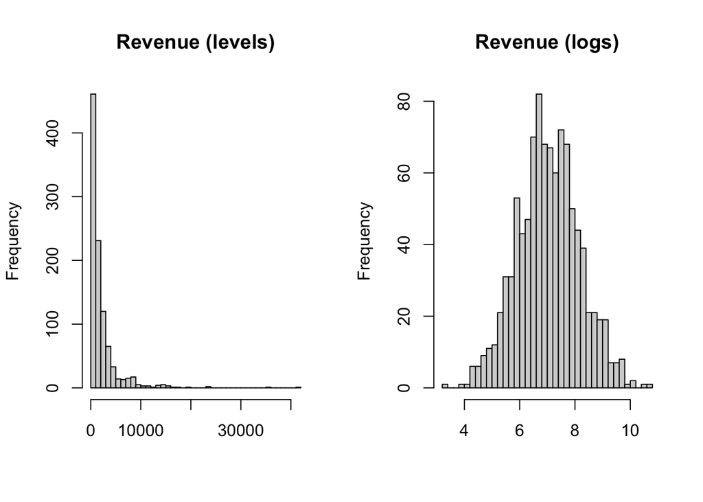

```r
n <- 1000
log_traffic <- rnorm(n, mean = 5, sd = 1)
log_revenue <- 2 + 1 * log_traffic + rnorm(n, sd = 0.5)
revenue <- exp(log_revenue); traffic <- exp(log_traffic)

par(mfrow = c(1, 2))
hist(revenue, breaks = 50, main = "Revenue (levels)", xlab = "")
hist(log(revenue), breaks = 50, main = "Revenue (logs)", xlab = "")
```

Now watch what one giant firm does to the levels regression and not the log one:

```r
# add one Walmart: enormous traffic and revenue, same elasticity
traffic2 <- c(traffic, 5e4); revenue2 <- c(revenue, exp(2) * 5e4 * 1.6)
rbind(
  levels_slope = c(without = coef(lm(revenue ~ traffic))[2],
                   with_walmart = coef(lm(revenue2 ~ traffic2))[2]),
  log_slope    = c(without = coef(lm(log(revenue) ~ log(traffic)))[2],
                   with_walmart = coef(lm(log(revenue2) ~ log(traffic2)))[2])
)
```

```
##              without.traffic with_walmart.traffic2
## levels_slope       8.0163056            11.6725316
## log_slope          0.9784358             0.9815603
```

One observation moved the levels slope; the log regression barely noticed.

# Reproduce: rare events, relative vs. absolute

```r
p0 <- 0.0002                       # baseline fraud rate: 2 in 10,000
p1 <- 2 * p0                       # "doubles the risk!"
c(relative_change = "+100%", absolute_change_pp = 100 * (p1 - p0))
```

```
##    relative_change absolute_change_pp
##            "+100%"             "0.02"
```

# In-class problem 1: recover a price elasticity (and prove units don’t matter)

Simulate weekly demand for a product across 500 store-weeks with a known price elasticity of $-2$: `log_q = 8 - 2*log(price) + noise`, where `price ~ Uniform(2, 6)` dollars and `noise ~ N(0, 0.3^2)`.

**(a)** Estimate the log–log regression. Interpret the slope in one sentence a pricing manager would understand. **(b)** Re-run with price measured in *cents* (multiply by 100). What happens to the slope? To the intercept? Why is this exactly what the lecture promised? **(c)** Now run the regression in *levels* (`q` on `price`, no logs) for both dollars and cents. What happens to the slope? One sentence: why do economists report elasticities instead of “units per dollar”?

```r
# your code here
```

# In-class problem 2: the log(0) trap (Chen–Roth, live)

Simulate 2,000 sellers on a platform. Half are randomly “promoted” (treatment). Weekly sales: each seller makes a sale with probability 0.3 if untreated and 0.5 if treated; *given* any sale, revenue is lognormal: `revenue = sold * exp(rnorm(n, mean = 3, sd = 1))` — so the data has lots of exact zeros.

**(a)** Estimate the treatment effect using `log(1 + revenue)` as the outcome. **(b)** Now measure revenue in *cents* instead of dollars and re-estimate. Compare (a) and (b). What just happened, and why is this disqualifying for a “percentage effect” interpretation? **(c)** Estimate a Poisson regression on the *level* of revenue (`fepois(revenue ~ treated, data = df)`) for both dollars and cents. What happens to the treatment coefficient now, and how do you interpret it? **(d)** Two sentences: separate what the promotion did to the *extensive* margin (any sale) from the *intensive* margin (revenue given a sale) — which margin is your Poisson coefficient mostly picking up here?

```r
# your code here
```